# Figure 1

John Favate

2022-07-14 16:10:33

```r
# Prevent printing of warnings and such in the HTML
knitr::opts_chunk$set(warning = FALSE, message = FALSE, fig.align = "center")
```

```r
library(tidyverse)
library(patchwork)
library(broom)
library(scales)
library(ggpubr)
library(parallel)
library(png)
library(grid)
library(sinib)
```

```r
mut.levels <- read_csv("../../data_frames/all_data.csv") %>%
  select(line, mutator) %>%
  arrange(mutator, line) %>%
  unique() %>%
  pull(line)

mut.colors <- c(rep("black", 6), rep("firebrick3", 5))

ddf <- read_csv("../../data_frames/table_s2_fold_changes.csv") %>%
  filter(seqtype == "rna") %>%
  mutate(line = factor(line, levels = mut.levels))

all.data <- read_csv("../../data_frames/all_data.csv") %>%
  filter(gene_type == "ECB")

# these are the mutator lines
mut.lines <- all.data %>%
  filter(mutator == TRUE) %>%
  pull(line) %>%
  unique()

# get the e coli proteins only
ecb.genes <- unique(all.data$target_id)

# Removes ERCC and tRNA genes from the data
kdf <- read_csv("../../data_frames/table_s1_read_counts.csv") %>%
  filter(target_id %in% ecb.genes)
```

Define the set of genes that were significant in any one line.

```r
sig.genes <- ddf %>%
  filter(padj <= .01) %>%
  pull(target_id) %>%
  unique()
```

A list of genes that were significant in a specific line.

```r
sigs.per.line <- ddf %>%
  filter(padj <= .01) %>%
  split(.$line) %>%
  map(.f = pull, target_id)

# add both ancestors to the list, but with no genes. This is so when a
# comparison between evo:anc comes up, only evo genes will be used as the
# significant set
sigs.per.line$"REL606" <- NA
sigs.per.line$"REL607" <- NA
```

### Panel A

The schematic figure

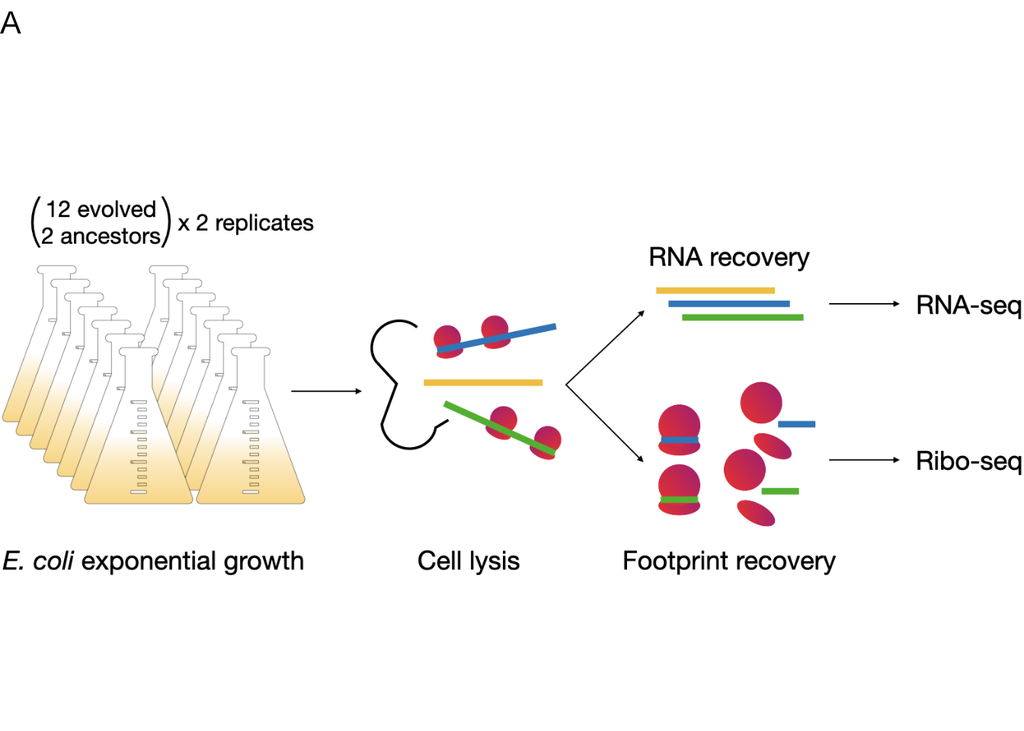

```r
png.a <-
  rasterGrob(readPNG("../figures/schematic_figure.png"), interpolate = TRUE)

# this is simply a dummy plot to hold the picture in
cartoon <- ggplot(mtcars, aes(hp, mpg)) +
  annotation_custom(
    grob = png.a,
    xmin = -Inf,
    xmax = Inf,
    ymin = -Inf,
    ymax = Inf
  ) +
  labs(x = NULL, y = NULL, title = "A") +
  theme_void() +
  theme(text = element_text(size = 13))

cartoon
```

### Panel B

Boxplot showing differences in TPMs as a function of who is being compared to who. If the pairwise comparison is between two evolved lines, then it uses the union of the significant genes between the two as the significant set. If it’s between an ancestor and an evolved line, then it uses the significant genes in the one evolved line as the significant set.

Average the TPMs across reps and log10 them

```r
mean.tpms <- kdf %>%
  filter(seqtype == "rna") %>%
  group_by(line, target_id) %>%
  summarise(mean_tpm = mean(tpm)) %>%
  ungroup() %>%
  mutate(mean_tpm = ifelse(mean_tpm != 0, log10(mean_tpm), NA))
```

Run all possible pairs of lines

```r
combos <- combn(unique(mean.tpms$line), m = 2, simplify = FALSE)
```

Do comparisons for all genes TPMs

```r
all.genes.cors <- lapply(combos, function(x) {
  # get the TPMs for the two lines in question
  tpms <- mean.tpms %>%
    filter(line %in% x) %>%
    pivot_wider(names_from = line, values_from = mean_tpm)

  # turn them to vectors
  t1 <- pull(tpms, x[1])
  t2 <- pull(tpms, x[2])

  # run the correlation test and add some columns, the who column specifies
  # anc:evo or evo:evo
  cor.test(t1, t2, method = "spearman") %>%
    tidy() %>%
    mutate(
      line1 = x[1],
      line2 = x[2],
      type = "All genes",
      who = ifelse(
        grepl("REL", line1) | grepl("REL", line2),
        "anc:evo",
        "evo:evo"
      )
    )
}) %>%
  bind_rows()

head(all.genes.cors)
```

| estimate | statistic | p.value | method | alternative | line1 | line2 | type | who |
| --- | --- | --- | --- | --- | --- | --- | --- | --- |
| 0.9553042 | 416878372 | 0 | Spearman's rank correlation rho | two.sided | Ara-1 | Ara-2 | All genes | evo:evo |
| 0.9425830 | 469556810 | 0 | Spearman's rank correlation rho | two.sided | Ara-1 | Ara-3 | All genes | evo:evo |
| 0.9653645 | 298846300 | 0 | Spearman's rank correlation rho | two.sided | Ara-1 | Ara-4 | All genes | evo:evo |
| 0.9524069 | 478537037 | 0 | Spearman's rank correlation rho | two.sided | Ara-1 | Ara-5 | All genes | evo:evo |
| 0.9601223 | 395160980 | 0 | Spearman's rank correlation rho | two.sided | Ara-1 | Ara-6 | All genes | evo:evo |
| 0.9496464 | 472232512 | 0 | Spearman's rank correlation rho | two.sided | Ara-1 | Ara+1 | All genes | evo:evo |

Then comparisons involving the union of significant genes

```r
# this one can't use the anc:anc pair because there is no significant genes
no.anc.anc.combos <-
  combos[!(grepl("REL606", combos) & grepl("REL607", combos))]

sig.genes.cors <- lapply(no.anc.anc.combos, function(x) {
  # find the union of the significant genes
  u.genes <- union(sigs.per.line[[x[1]]],
                   sigs.per.line[[x[2]]]) %>%
    na.omit()

  # get the TPMs for the two lines in question, only keep significant set genes
  tpms <- mean.tpms %>%
    filter(line %in% x & target_id %in% u.genes) %>%
    pivot_wider(names_from = line, values_from = mean_tpm)

  # turn them to vectors
  t1 <- pull(tpms, x[1])
  t2 <- pull(tpms, x[2])

  # run the correlation test and add some columns, the who column specifies
  # anc:evo or evo:evo
  cor.test(t1, t2, method = "spearman") %>%
    tidy() %>%
    mutate(
      line1 = x[1],
      line2 = x[2],
      type = "Differentially\nexpressed",
      who = ifelse(
        grepl("REL", line1) | grepl("REL", line2),
        "anc:evo",
        "evo:evo"
      )
    )
}) %>%
  bind_rows()

head(sig.genes.cors)
```

| estimate | statistic | p.value | method | alternative | line1 | line2 | type | who |
| --- | --- | --- | --- | --- | --- | --- | --- | --- |
| 0.7875201 | 7959324 | 0 | Spearman's rank correlation rho | two.sided | Ara-1 | Ara-2 | Differentially\nexpressed | evo:evo |
| 0.8063882 | 3658598 | 0 | Spearman's rank correlation rho | two.sided | Ara-1 | Ara-3 | Differentially\nexpressed | evo:evo |
| 0.8127989 | 859356 | 0 | Spearman's rank correlation rho | two.sided | Ara-1 | Ara-4 | Differentially\nexpressed | evo:evo |
| 0.6770850 | 1482358 | 0 | Spearman's rank correlation rho | two.sided | Ara-1 | Ara-5 | Differentially\nexpressed | evo:evo |
| 0.6049998 | 898736 | 0 | Spearman's rank correlation rho | two.sided | Ara-1 | Ara-6 | Differentially\nexpressed | evo:evo |
| 0.6096117 | 3486314 | 0 | Spearman's rank correlation rho | two.sided | Ara-1 | Ara+1 | Differentially\nexpressed | evo:evo |

```r
all.cors.b <- bind_rows(all.genes.cors, sig.genes.cors)
```

KS test those distributions

```r
ks.res <- all.cors.b %>%
  split(.$type) %>%
  map(function(x) {
    evoevo <- x[x$who == "evo:evo",]$estimate

    ancevo <- x[x$who == "anc:evo",]$estimate

    ks.test(evoevo, ancevo) %>%
      broom::tidy()
  }) %>%
  bind_rows(.id = "type") %>%
  mutate(labz = paste("p =", signif(p.value, 2)))
```

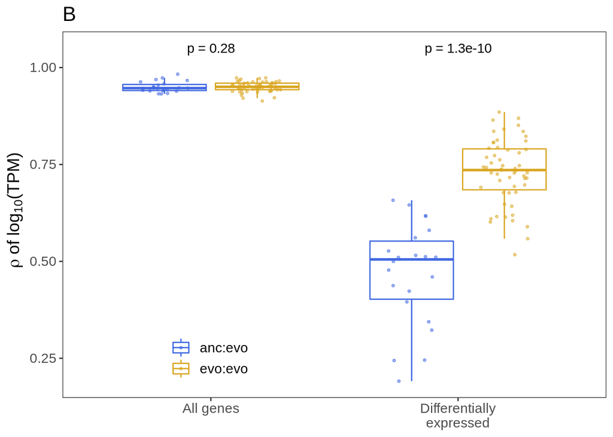

```r
pb <- all.cors.b %>%
  ggplot(., aes(type, estimate, color = who)) +
  geom_boxplot(outlier.colour = NA) +
  geom_jitter(
    position = position_jitterdodge(jitter.height = 0, jitter.width = .2),
    size = .75,
    alpha = .5
  ) +
  scale_color_manual(values = c("royalblue", "goldenrod"), name = NULL) +
  theme_bw() +
  theme(
    text = element_text(size = 14),
    panel.grid = element_blank(),
    legend.position = c(.27, .12),
    legend.background = element_blank(),
    axis.title.x = element_blank()
  ) +
  labs(x = NULL,
       y = expression(paste( ~ rho, " of ", log[10], "(TPM)", sep = "")),
       title = "B") +
  geom_text(inherit.aes = FALSE,
            data = ks.res,
            aes(type, y = 1.05, label = labz))

pb
```

### Panel C

Correlations based on fold changes, again for the union of significant genes between each pairwise comparison

```r
evo.pairs <- combn(unique(ddf$line), m = 2, simplify = FALSE)

all.cors.c <- lapply(evo.pairs, function(x) {
  # all fold changes
  all.fc <- ddf %>%
    filter(line %in% x) %>%
    select(line, target_id, log2FoldChange) %>%
    pivot_wider(names_from = line, values_from = log2FoldChange)

  # union of sig genes
  sig.union <- union(sigs.per.line[[x[1]]],
                     sigs.per.line[[x[2]]])

  # the sig fold changes
  sig.fc <- ddf %>%
    filter(line %in% x & target_id %in% sig.union) %>%
    select(line, target_id, log2FoldChange) %>%
    pivot_wider(names_from = line, values_from = log2FoldChange)

  # calculate correlations
  sig.cors <- cor.test(pull(sig.fc, x[1]),
                       pull(sig.fc, x[2]),
                       method = "spearman") %>%
    tidy() %>%
    mutate(line1 = x[1],
           line2 = x[2],
           set = "Differentially\nexpressed")

  all.cors <- cor.test(pull(all.fc, x[1]),
                       pull(all.fc, x[2]),
                       method = "spearman") %>%
    tidy() %>%
    mutate(line1 = x[1],
           line2 = x[2],
           set = "All genes")

  # join them
  both.cors <- bind_rows(sig.cors, all.cors)
}) %>%
  bind_rows()

all.cors.c
```

| estimate | statistic | p.value | method | alternative | line1 | line2 | set |
| --- | --- | --- | --- | --- | --- | --- | --- |
| 0.5570412 | 16674882 | 0.000000e+00 | Spearman's rank correlation rho | two.sided | Ara-1 | Ara-2 | Differentially\nexpressed |
| 0.4383498 | 5484692876 | 3.921774e-182 | Spearman's rank correlation rho | two.sided | Ara-1 | Ara-2 | All genes |
| 0.4374363 | 10762854 | 0.000000e+00 | Spearman's rank correlation rho | two.sided | Ara-1 | Ara-3 | Differentially\nexpressed |
| 0.1887146 | 7119035259 | 2.181998e-31 | Spearman's rank correlation rho | two.sided | Ara-1 | Ara-3 | All genes |
| 0.6498632 | 1705038 | 0.000000e+00 | Spearman's rank correlation rho | two.sided | Ara-1 | Ara-4 | Differentially\nexpressed |
| 0.5425538 | 4259921591 | 1.226908e-291 | Spearman's rank correlation rho | two.sided | Ara-1 | Ara-4 | All genes |
| 0.5628483 | 2067168 | 0.000000e+00 | Spearman's rank correlation rho | two.sided | Ara-1 | Ara-5 | Differentially\nexpressed |
| 0.4223054 | 6199121785 | 3.988774e-173 | Spearman's rank correlation rho | two.sided | Ara-1 | Ara-5 | All genes |
| 0.5871348 | 939384 | 0.000000e+00 | Spearman's rank correlation rho | two.sided | Ara-1 | Ara-6 | Differentially\nexpressed |
| 0.4694022 | 5537501129 | 8.286225e-217 | Spearman's rank correlation rho | two.sided | Ara-1 | Ara-6 | All genes |

[output cut: 100 more lines]

Run KS tests on the comparisons.

```r
fc.ks.res <- ks.test(all.cors.c[all.cors.c$set == "All genes",]$estimate,
                     all.cors.c[all.cors.c$set == "Differentially\nexpressed",]$estimate)

plabel <- paste("p =",
                signif(fc.ks.res$p.value, 2))
```

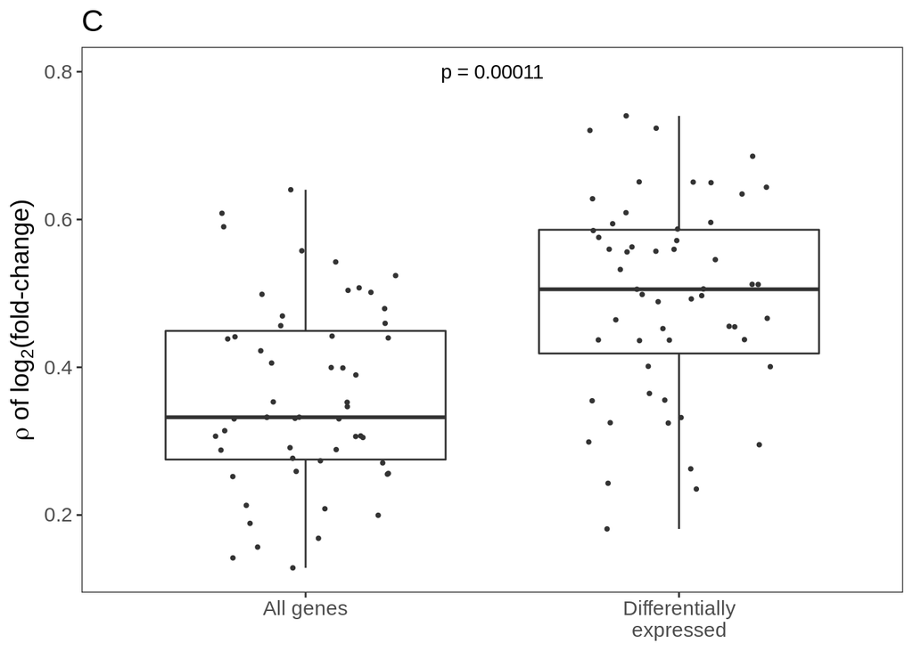

```r
pc <- all.cors.c %>%
  ggplot(., aes(set, estimate)) +
  geom_boxplot(outlier.color = NA) +
  geom_jitter(
    height = 0,
    size = .75,
    width = .25,
    color = "grey20"
  ) +
  theme_bw() +
  theme(panel.grid = element_blank(),
        text = element_text(size = 14)) +
  labs(y = expression(paste(rho, " of ", log[2], "(fold-change)", sep = "")),
       x = NULL,
       title = "C") +
  annotate("text",
           label = plabel,
           x = 1.5,
           y = .8)

pc
```

### Panel D

Heatmap of fold changes for the superset of significant genes.

```r
gene.order <- ddf %>%
  filter(target_id %in% sig.genes) %>%
  group_by(target_id) %>%
  summarise(mean_fc = mean(log2FoldChange, na.rm = TRUE)) %>%
  arrange(mean_fc) %>%
  pull(target_id)
```

Scale labels

```r
threshold <- 3

scale.labels <- c(paste("\u2264", paste0("-", threshold), sep = ""),
                  "",
                  0,
                  "",
                  paste("\u2265", threshold, sep = ""))
```

The df for the plot

```r
pd.df <- ddf %>%
  filter(seqtype == "rna" & target_id %in% sig.genes) %>%
  mutate(
    target_id = factor(target_id, levels = gene.order),
    newfc = case_when(
      log2FoldChange < -3 ~ -3,
      log2FoldChange > 3 ~ 3,
      is.na(log2FoldChange) | TRUE ~ log2FoldChange
    )
  ) %>%
  select(line, target_id, newfc)

pd.df
```

| line | target_id | newfc |
| --- | --- | --- |
| Ara-1 | ECB_00001 | -3.679303e-01 |
| Ara-1 | ECB_00002 | -8.413293e-01 |
| Ara-1 | ECB_00003 | -1.064649e+00 |
| Ara-1 | ECB_00004 | -1.075328e+00 |
| Ara-1 | ECB_00005 | -9.459255e-01 |
| Ara-1 | ECB_00008 | -3.847075e-01 |
| Ara-1 | ECB_00010 | 8.308701e-01 |
| Ara-1 | ECB_00014 | -1.148266e-01 |
| Ara-1 | ECB_00015 | -2.371864e-01 |
| Ara-1 | ECB_00017 | -7.318729e-01 |

[output cut: 9990 more lines]

Get clustering order to cluster line on the heatmap

```r
d.clust <- pd.df %>%
  pivot_wider(names_from = target_id, values_from = newfc) %>%
  column_to_rownames("line") %>%
  dist() %>%
  hclust()

d.line.order <- setNames(d.clust$order, d.clust$labels) %>%
  sort() %>%
  names()

pd.df$line <- factor(pd.df$line, d.line.order)
```

Get the correct colors for the labels

```r
d.colors <- sapply(d.line.order, function(x){
  if (x %in% mut.lines){
    return("firebrick")
  } else {
    return("black")
  }
})
```

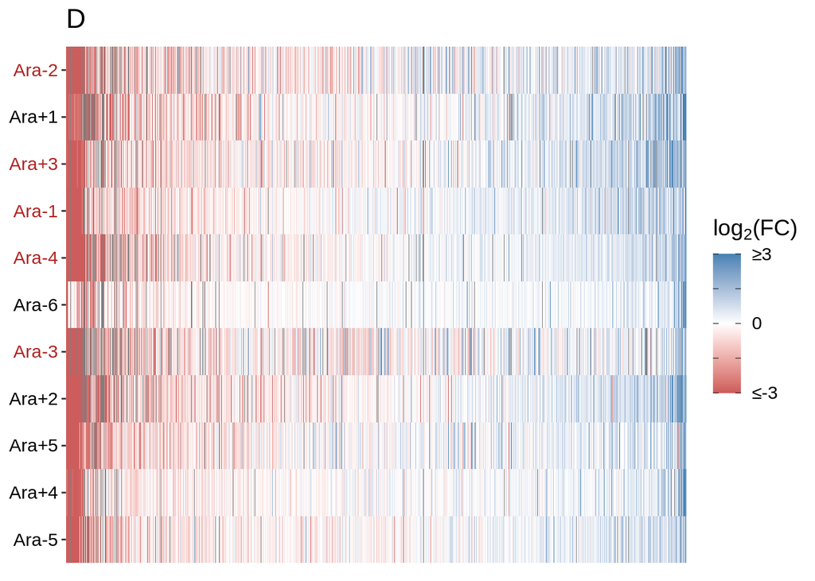

```r
pd <- pd.df %>%
  ggplot(., aes(target_id, line, fill = newfc)) +
  geom_raster() +
  scale_fill_gradientn(
    colors = c("indianred", "white", "steelblue"),
    labels = scale.labels,
    breaks = c(-3,-1.5, 0, 1.5, 3),
    name = expression(paste(log[2], "(FC)")),
    guide = guide_colorbar(ticks.colour = "black")
  ) +
  theme(
    panel.background = element_blank(),
    panel.grid = element_blank(),
    text = element_text(size = 14),
    axis.ticks.x = element_blank(),
    axis.text.x = element_blank(),
    axis.text.y = element_text(color = d.colors)
  ) +
  labs(x = NULL,
       y = NULL,
       title = "D")

pd
```

### Panel E

This is how many many genes (nn) were significant in n lines, separated by up and downregulated.

```r
obs.sig.counts <- ddf %>%
  filter(padj <= .01) %>%
  mutate(direc = ifelse(log2FoldChange > 0, "up", "down")) %>%
  group_by(target_id, direc) %>%
  tally() %>%
  ungroup() %>%
  group_by(direc, n) %>%
  tally() %>%
  ungroup() %>%
  add_case(direc = "up", n = 10, nn = 0) # there's no up n=10 case, add it.

# total down genes
total.down <-
  sum(obs.sig.counts[obs.sig.counts$direc == "down",]$nn)

# total up genes
total.up <- sum(obs.sig.counts[obs.sig.counts$direc == "up",]$nn)

# total possible genes
total.genes <- length(unique(ddf$target_id))

# prob of not being sig down
prob.not.sig.down <- (total.genes - total.down) / total.genes


# prob of not being sig up
prob.not.sig.up <- (total.genes - total.up) / total.genes

# add the zero case, i.e. n genes that aren't sig and calc probs
obs.sig.counts <- obs.sig.counts %>%
  add_case(direc = "down",
           n = 0,
           nn = (total.genes - total.down)) %>%
  add_case(direc = "up",
           n = 0,
           nn = (total.genes - total.up)) %>%
  arrange(direc, n) %>%
  group_by(direc) %>%
  mutate(prob = nn / sum(nn)) %>%
  ungroup()

obs.sig.counts
```

| direc | n | nn | prob |
| --- | --- | --- | --- |
| down | 0 | 3407 | 0.824340673 |
| down | 1 | 391 | 0.094604404 |
| down | 2 | 137 | 0.033147835 |
| down | 3 | 73 | 0.017662715 |
| down | 4 | 47 | 0.011371885 |
| down | 5 | 24 | 0.005806920 |
| down | 6 | 11 | 0.002661505 |
| down | 7 | 6 | 0.001451730 |
| down | 8 | 4 | 0.000967820 |
| down | 9 | 4 | 0.000967820 |

[output cut: 14 more lines]

They are separate plots but make up a single panel. This is the top panel

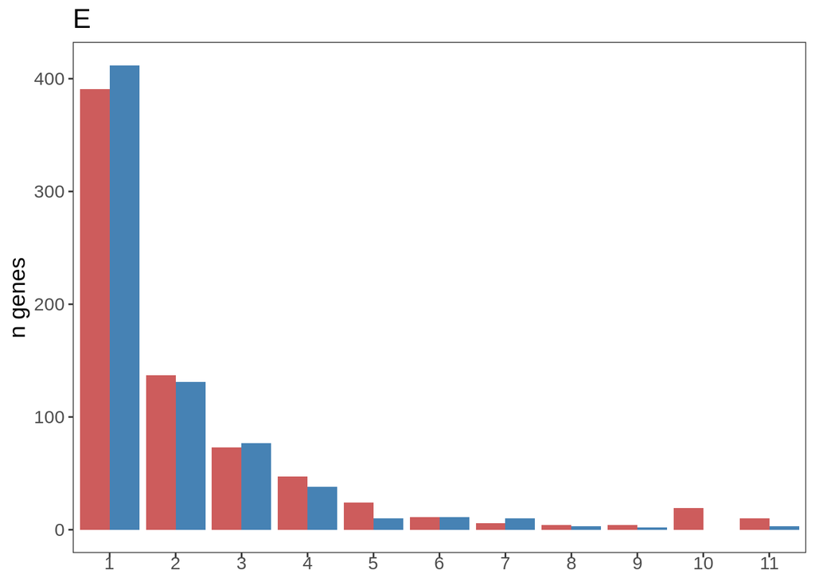

```r
rats.top <- obs.sig.counts %>%
  filter(n != 0) %>%
  ggplot(., aes(as.numeric(n), nn, fill = direc)) +
  geom_col(position = position_dodge(preserve = "single")) +
  scale_x_continuous(breaks = 0:11, expand = c(.01, 0)) +
  theme_bw() +
  theme(
    text = element_text(size = 14),
    panel.grid = element_blank(),
    axis.title.x = element_blank(),
    axis.text.x = element_text(margin = margin(l = 0, r = 1))
  ) +
  scale_fill_manual(
    values = c("indianred", "steelblue"),
    name = NULL,
    labels = c("Downregulated",
               "Upregulated"),
    guide = "none"
  ) +
  labs(x = NULL,
       y = "n genes",
       title = "E")

rats.top
```

A zoom of that because the 0 case is too large

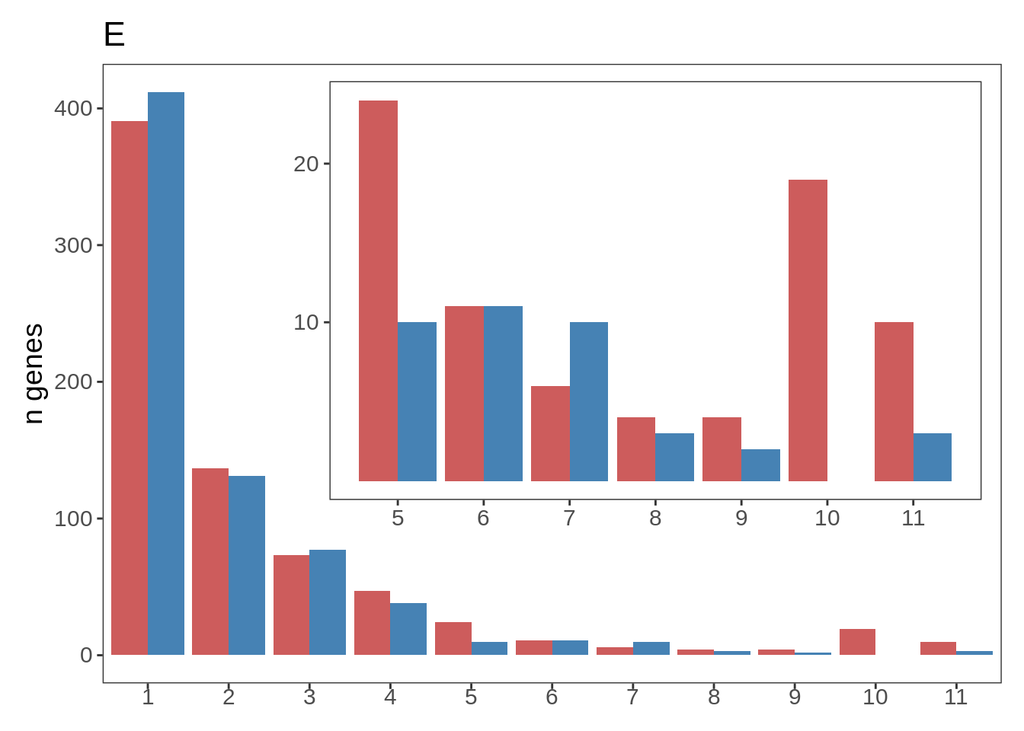

```r
p.zoom <- obs.sig.counts %>%
  filter(n >= 5) %>%
  ggplot(., aes(as.numeric(n), nn, fill = direc)) +
  geom_col(position = position_dodge(preserve = "single")) +
  scale_x_continuous(breaks = 1:11) +
  theme_bw() +
  theme(
    text = element_text(size = 14),
    panel.grid = element_blank(),
    axis.title.x = element_blank(),
    panel.background = element_blank()
  ) +
  scale_fill_manual(
    values = c("indianred", "steelblue"),
    name = NULL,
    labels = c("Downregulated",
               "Upregulated"),
    guide = "none"
  ) +
  labs(x = NULL,
       y = NULL) +
  scale_y_continuous(breaks = c(10,20))

(rats.top <-
    rats.top + inset_element(
      p.zoom,
      left = .2,
      bottom = .23,
      right = .99,
      top = .99
    ))
```

Find the probability of being down or upregulated in a specific line, i.e. the number of genes sig down / number of genes in that line where number of genes in a line is the number of genes that are not deleted

```r
probs <- ddf %>%
  filter(seqtype == "rna") %>%
  split(.$line) %>%
  map(function(x) {
    # number of non deleted genes
    n.genes <- x %>%
      filter(deleted == FALSE) %>%
      nrow()

    # prob downreg
    p.down <- x %>%
      filter(padj <= .01 & log2FoldChange < 0) %>%
      nrow() / n.genes

    # prob upreg
    p.up <- x %>%
      filter(padj <= .01 & log2FoldChange > 0) %>%
      nrow() / n.genes

    data.frame(n.genes = n.genes,
               p.up = p.up,
               p.down = p.down)
  }) %>%
  bind_rows(.id = "line")
```

Find the expected distributions

```r
# the down distribution
p.down <- dsinib(x = 0:11, # chance of getting 0,1,2...,11 success
                 size = rep(1, 11), # pick 1 gene
                 prob = probs$p.down)

# the up distribution
p.up <- dsinib(x = 0:11, # chance of getting 0,1,2...,11 success
               size = rep(1, 11), # pick 1 gene
               prob = probs$p.up)

# observed prob of up
obs.up <- obs.sig.counts[obs.sig.counts$direc == "up",]$prob

# observed prob of down
obs.down <- obs.sig.counts[obs.sig.counts$direc == "down",]$prob

# combine to single df
pdf <- data.frame(
  n = 0:11,
  "Exp_up" = p.up,
  "Exp_down" = p.down,
  "Obs_up" = obs.up,
  "Obs_down" = obs.down
)

# make 10 up NA so it doesn't graph because there isn't a point there
pdf[pdf$n == 10,]$Obs_up <- NA

# save this so it can be used in fig s2
write_rds(pdf, "../../data_frames/fig_1_probs.rds")

# also make a fake data frame that allows connection of the points at n = 9 and
# n = 11 for obs up
connect.df <- data.frame(
  n = c(9, 11),
  name = rep("Obs_up"),
  value = c(pdf[pdf$n == 9,]$Obs_up, pdf[pdf$n == 11,]$Obs_up)
)
```

The expected total number of genes one would find in x number of lines, 4131 is number of ECB genes considered.

```r
exp <- sapply(1:11, function(x) {
  # total number of down genes expected in some number of lines and up x
  find.down <- (p.down * 4131)[x:11] %>% sum()

  find.up <- (p.up * 4131)[x:11] %>% sum()

  n.genes <- floor(find.up + find.down)

  return(setNames(n.genes, x))
})

exp
```

```
##    1    2    3    4    5    6    7    8    9   10   11
## 8262 2644  438   44    3    0    0    0    0    0    0
```

The actual number

```r
obs <- sapply(1:11, function(x) {
  obs.sig.counts %>%
    filter(n >= x) %>%
    pull(nn) %>%
    sum() %>%
    setNames(., x)
})

obs
```

```
##    1    2    3    4    5    6    7    8    9   10   11
## 1423  620  352  202  117   83   61   45   38   32   13
```

KS test the various distributions

```r
up.p <- ks.test(pdf$Exp_up, na.omit(pdf$Obs_up))$p.value %>%
  signif(2) %>%
  paste("p =", .)

down.p <- ks.test(pdf$Exp_down, na.omit(pdf$Obs_down))$p.value %>%
  signif(2) %>%
  paste("p =", .)
```

Plot it

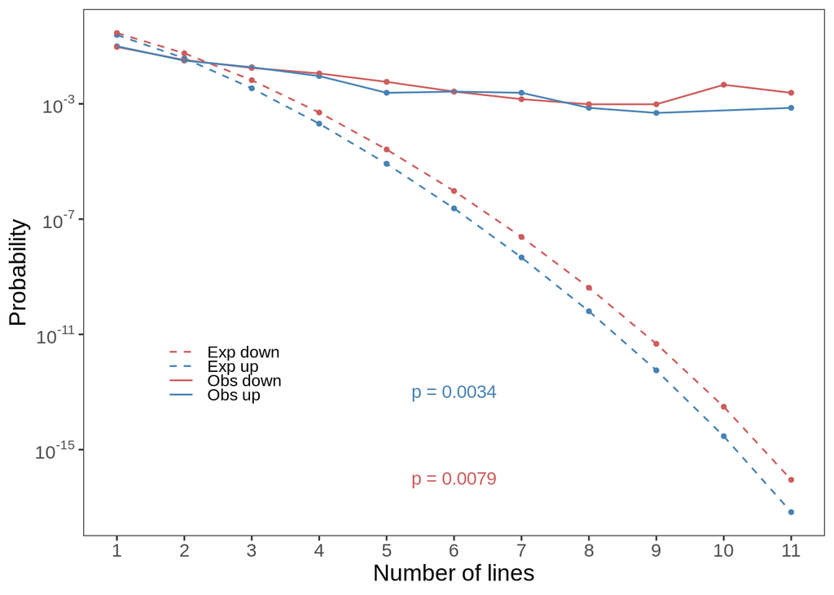

```r
rats.bottom <- pdf %>%
  filter(n != 0) %>%
  pivot_longer(cols = c(starts_with("Ex"), starts_with("Obs"))) %>%
  mutate(name = str_replace(name, "_", " ")) %>%
  ggplot(., aes(as.numeric(n), value, color = name, linetype = name)) +
  geom_point(show.legend = FALSE, size = 1) +
  geom_line() +
  geom_line(inherit.aes = FALSE,
            data = connect.df,
            aes(n, value),
            color = "steelblue") +
  scale_color_manual(values = c("indianred", "steelblue", "indianred", "steelblue")) +
  scale_linetype_manual(values = c("dashed", "dashed", "solid", "solid")) +
  theme_bw() +
  theme(
    panel.grid = element_blank(),
    text = element_text(size = 14),
    legend.position = c(.19, .32),
    legend.title = element_blank(),
    legend.background = element_blank(),
    legend.text = element_text(size = 10),
    legend.key.height = unit(3, "mm")
  ) +
  scale_x_continuous(breaks = 0:11) +
  labs(x = "Number of lines",
       y = "Probability") +
  scale_y_log10(labels = trans_format("log10", math_format(10 ^ .x)),
                breaks = breaks_log(6)) +
  annotate(
    "text",
    label = up.p,
    x = 6,
    y = 10e-14,
    color = "steelblue"
  ) +
  annotate(
    "text",
    label = down.p,
    x = 6,
    y = 10e-17,
    color = "indianred"
  )

rats.bottom
```

Together

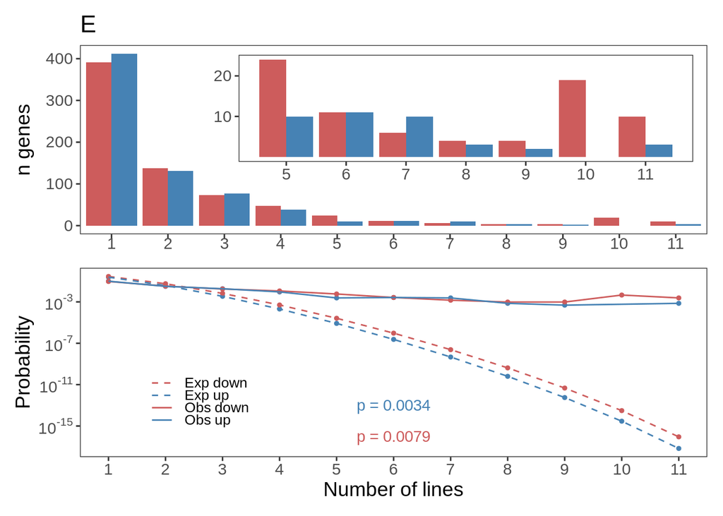

```r
(pe <- rats.top / rats.bottom)
```

### Final figure

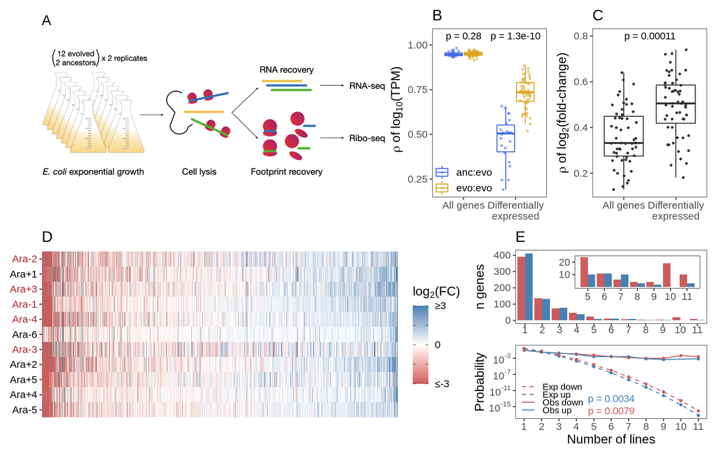

```r
top <- (cartoon | pb | pc) + plot_layout(widths = c(.6, .2, .2))

bottom <- (pd | pe) + plot_layout(widths = c(.65, .35))

(ff <- top / bottom)
```

Save it in various formats

```r
ggsave(ff, filename = "../../figures/fig_1.png", width = 11, height = 7)

ggsave(ff, filename = "../../figures/fig_1.pdf", device = cairo_pdf, width = 11, height = 7)

write_rds(ff, "../../figures/fig_1.rds")
```